# Aligning topics

Kris, Laura & Julia

1/20/2021

# Objectives

We aim at developing a method to align and compare topics when

1. the number of topics is changed (varying K)
2. hyper-parameters of LDA are changed (e.g. varying alpha)
3. different modalities [? is there a better term than “modality” ?] exists for the same documents. For example, the same set of documents exists in different languages but we don’t have a direct translation of each word. Or, more commonly encountered in biology, the same samples have been analyzed for different -omics information, *e.g.* metagenomic or transcriptomic, and there is a desire to compare the topics from these different domains.

# Notations

**Models**

We aim to compare the topics of $M$ LDA models. Each specific model is denoted by $m \in [1:M]$.

**Topics**

Each model $M$ has $K$ topics. Each topic is denoted by $k \in [1:K]$.

**Documents (Samples)**

The dataset is composed of $D$ documents (or samples). Each document/sample is denoted by $d \in [1:D]$.

**Words (features)**

The dataset contains counts for a set of $W$ words (or features). In biology, these features would be genes, transcripts, proteins, bacterial species, etc. Each word is denoted by an index $w \in [1:W]$. The number of word $w$ found in a specific document $d$ is denoted by $c_{w,d}$.

**LDA model matrices**

LDA models are defined by two matrices:

- $\beta$, which is a $K \times W$ matrix where element $\beta_{k,w}$ provides the proportion of word $w$ in topic $k$, and
- $\gamma$, which is a $D \times K$ matrix where element $\gamma_{d,k}$ provides the proportion of topic $k$ in document $d$.

In order words, an LDA finds topics such that each document is optimally described as a mixture of topics ($\gamma$), themselves characterized by a word probability ($\beta$).

# Aligning topics.

For objectives (1) and (2), we can align topics using the $\beta$ matrices from each model $m$, while for objective (3), only matrix $\gamma$ can be used to align topics.

We will thus first consider the problem of aligning topics using the $\gamma$ matrices, then consider the “inverse” problem of aligning topics using the $\beta$ matrices and discuss similarities and differences.

In both case, in addition to aligning topics between successive models (*e.g.* successive values of K or $alpha$, or manually ordered modalities), we are also interested in computing and visualizing the alignment between each model and a reference model $m^R$.

## Aligning topics based on the $\gamma$ matrices

First, each document $d$ is assigned a topic of reference $k_R$ which is defined as the topic of the reference model $m_R$ with the largest proportion for this document: $k^R_d = \arg \max \gamma_{d,k^R}$.

We then compute the proportion of mass transferred between each topic of successive models as $w^{\gamma}_{k^m, k^{m+1}} = \frac{1}{D} \sum_{d}^D \gamma_{d,k^m} \ \gamma_{d, k^{m+1}}$

Consequently, the “height” of each topic $h_{k^m}$ is $h_{k^m} = \sum_d \gamma_{d,k^m}$. Topics that are the main topics of many documents have a larger “height” that topics that are secondary topics of many documents or the main topic of few documents.

## Aligning topics based on the $\beta$ matrices

To align topics based on the distribution of word probability in these topics, we first define the following concepts:

- the average word frequency: $f_w = \frac{1}{D} \sum_d^D f_{w,d}$ with $f_{w,d} = \frac{c_{w,d}}{\sum_w^W c_{w,d}}$
- the “topic height”: $h_{k^m} = \sum_w^W f_w \ \beta_{w,k}$
- the “reference topic height” in each topic: $h_{k^m, k^R} = \sum_w^{W^R} f_w \ \beta_{w,k^m}$

[NOTE: these definitions are sufficient to draw the composition of each topic for each $m$, but to draw the flow between the topics, we need to find the optimal mass transfer - I kept writing down my notes, but it’s not super useful and it’s not implemented, instead, I implemented something a little ugly for the visualization of the flows]

# Implementation

Below is an example of how these functions are used on vaginal microbiome data.

## Example 1: varying $K$

```r
# Libraries to attach
library(tidyverse)
library(magrittr)
```

```r
library(topicmodels)
library(slam)

# load the topic alignment functions
source("align_topic_functions.R")

# viz default theme
theme_set(theme_minimal())
```

```r
load(file = "vm_16s_data.Rdata", verbose = TRUE)
```

```
## Loading objects:
##   vm_16s
```

```r
vm_16s <- slam::as.simple_triplet_matrix(vm_16s %>%  round())
```

```r
topic_models_dir = "lda_models/"

lda_models =
  run_lda_models(
    data = vm_16s,
    Ks = 1:13,
    method = "VEM",
    seed = 2,
    dir = topic_models_dir
  )

names(lda_models)
```

```
## [1] "betas"  "gammas"
```

```r
head(lda_models$betas)
```

```
## # A tibble: 6 x 5
##   m         K k_LDA w                                                          b
##   <fct> <dbl> <chr> <chr>                                                  <dbl>
## 1 1         1 a     Bacteria Firmicutes Bacilli Lactobacillales Lactobac… 0.297
## 2 1         1 a     Bacteria Firmicutes Bacilli Lactobacillales Lactobac… 0.239
## 3 1         1 a     Bacteria Firmicutes Bacilli Lactobacillales Lactobac… 0.0353
## 4 1         1 a     Bacteria Firmicutes Bacilli Lactobacillales Lactobac… 0.0448
## 5 1         1 a     Bacteria Firmicutes Negativicutes Selenomonadales Ve… 0.0346
## 6 1         1 a     Bacteria Firmicutes Bacilli Lactobacillales Lactobac… 0.0392
```

```r
head(lda_models$gammas)
```

```
## # A tibble: 6 x 5
##   m         K k_LDA d              g
##   <fct> <dbl> <chr> <chr>      <dbl>
## 1 1         1 a     1005601068     1
## 2 1         1 a     1005601078     1
## 3 1         1 a     1005601088     1
## 4 1         1 a     1005601098     1
## 5 1         1 a     1005601108     1
## 6 1         1 a     1005601118     1
```

```r
trimmed_lda_models =
  trim_models(
    models = lda_models,
    min_prop = 0.025)

dim(lda_models$betas)
```

```
## [1] 245609      5
```

```r
dim(trimmed_lda_models$betas)
```

```
## [1] 4732    5
```

```r
aligned_topics =
  align_topics(
    data = asv_for_topic,
    lda_models = trimmed_lda_models
  )

names(aligned_topics)
```

```
## [1] "lda_models"      "gamma_alignment" "topics_order"
```

```r
head(aligned_topics$gamma_alignment)
```

```
## # A tibble: 6 x 10
##   m     m_next m_ref k_LDA k_LDA_next k_LDA_ref       w     k k_next k_ref
##   <fct> <fct>  <fct> <chr> <chr>      <chr>       <dbl> <int>  <int> <int>
## 1 1     2      13    a     a          a         0.00639     1      1     3
## 2 1     2      13    a     a          b         0.0104      1      1    13
## 3 1     2      13    a     a          c         0.00110     1      1    10
## 4 1     2      13    a     a          d         0.0141      1      1    12
## 5 1     2      13    a     a          e         0.00467     1      1     4
## 6 1     2      13    a     a          f         0.0666      1      1     5
```

```r
# head(aligned_topics$beta_alignment) # not implemented
```

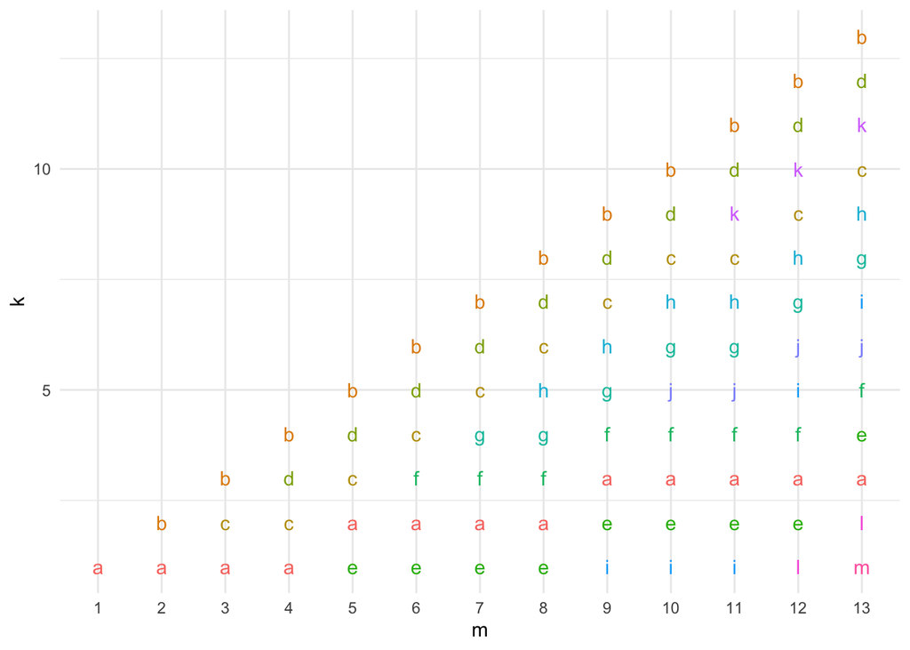

```r
ggplot(aligned_topics$topics_order, aes(x = m, y = k, col = k_LDA)) +
  geom_text(aes(label = k_LDA)) + guides(col = FALSE)
```

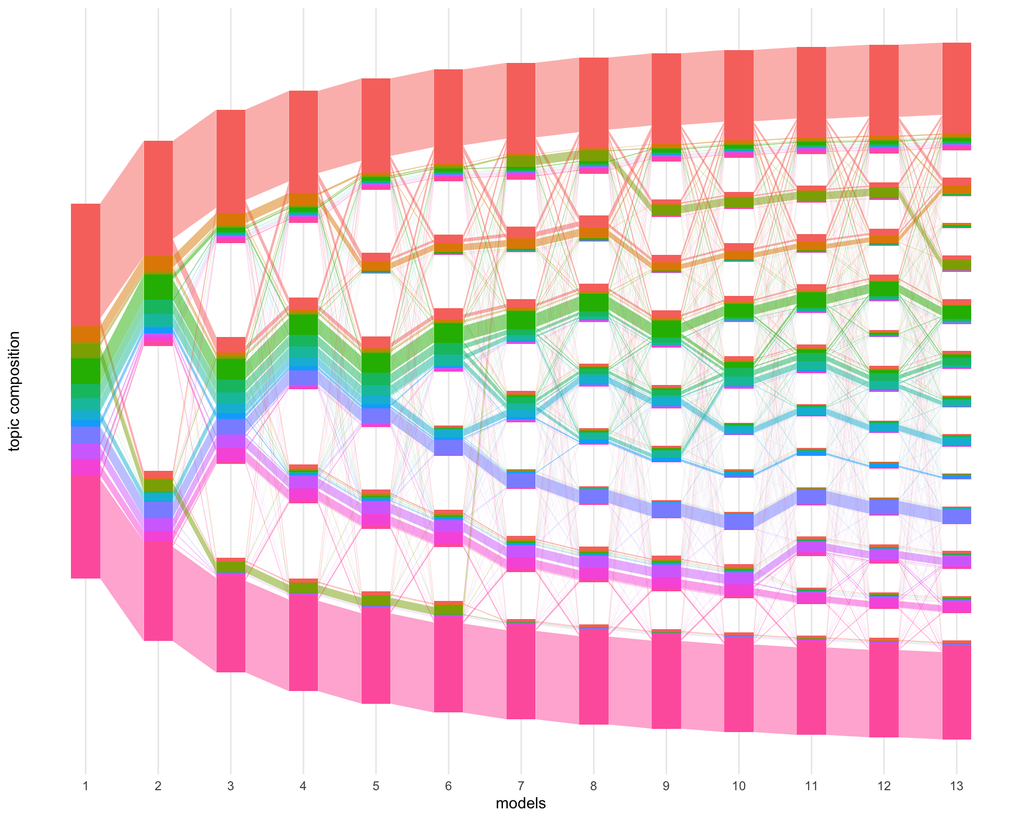

```r
g_aligned_topics =
  visualize_aligned_topics(
    aligned_topics = aligned_topics
    )

g_aligned_topics
```